# Project 2: Data Mining, Classification, Prediction

SDS322E

# Mining, Classification, Prediction

## Mohamed Bettayeb, mb58422

### Introduction

My dataset consists of data collected from incidents of heart failures at hospitals. The variables included in this dataset are age, anaemia, creatinine_phosphokinase, diabetes, ejection_fraction, high_blood_pressure, platelets, serum_creatinine, serum_sodium, sex, smoking, time, and DEATH_EVENT. I found this data on kaggle.com. My variables are measuring certian statuses and data collected by the hospitals of the patients that had an incident of heart failure. Age marks the age of the patient. Anaemia marks whether or not the patient had a deficiency in red blood cells. Creatinine_phosphokinase, serum_creatinine, aand serum_sodium are variables that measure how much of their respective chemicals are in the patient’s bloodstream. Ejection fraction measures the amount of blood leaving the heart. Diabetes marks whether or not the patient has diabetes. High_blood_pressure marks whether or not the patient has high blood pressure. Platelets measures the platelet count of the patient. Sex marks the sex of the patient. Smoking marks whether or not the patient is a smoker. Time measures the follow-up period. DEATH_EVENT marks whether or not this heart failure was fatal. I found this data particularly interesting as it has a lot to do with a particular field that I am interested in pursuing a career in one day; cardiology. There are approximately 299 observations of all 13 variables.

```r
library(tidyverse)
library(dplyr)
library(readr)
library(gt)
# read your datasets in here, e.g., with read_csv()
heart_failure <- read_csv("heart_failure_clinical_records_dataset.csv")
# if your dataset needs tidying, do so here

# any other code here
```

### Cluster Analysis

```r
library(cluster)
library(ggplot2)
library(GGally)
pam_data <-heart_failure %>% select(age, creatinine_phosphokinase, ejection_fraction, platelets, serum_creatinine, serum_sodium, time)
sil_width <- vector()
for (i in 2:10){
  pam_fit <- pam(pam_data, k = i)
  sil_width[i] <- pam_fit$silinfo$avg.width
}
pam_fit <- pam(pam_data, k = 9)
pam_fit$silinfo$avg.width
```

```
## [1] 0.592498
```

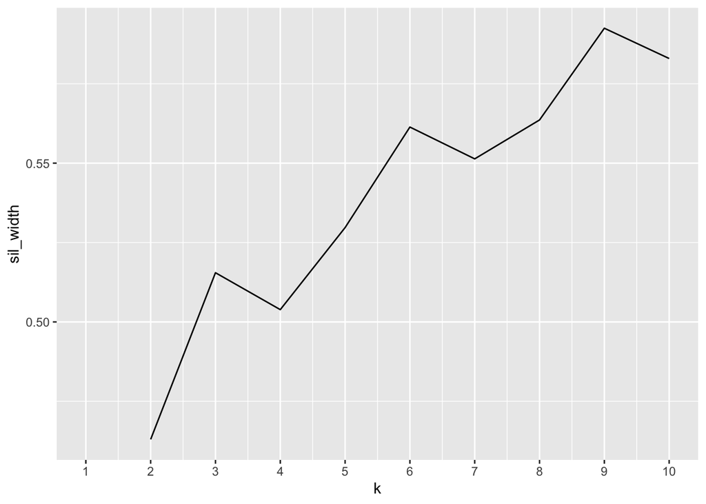

```r
ggplot() + geom_line(aes(x=1:10, y=sil_width)) + scale_x_continuous(name="k", breaks=1:10)
```

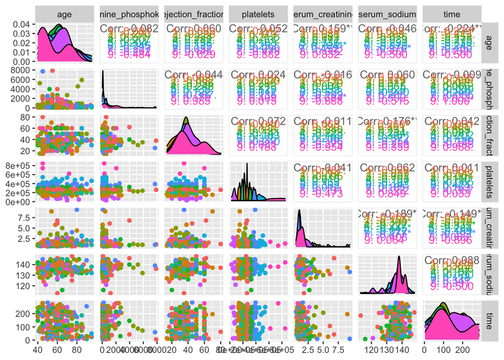

```r
# 9 is the ideal k
pam1 <- heart_failure %>% select(age, creatinine_phosphokinase, ejection_fraction, platelets, serum_creatinine, serum_sodium, time) %>% pam(k=9)
pamclust <- heart_failure %>% select(age, creatinine_phosphokinase, ejection_fraction, platelets, serum_creatinine, serum_sodium, time) %>% mutate(cluster=as.factor(pam1$clustering))
ggpairs(pamclust, columns = 1:7,aes(color=cluster))
```

```r
pamclust %>% group_by(cluster) %>% summarize_if(is.numeric,
    mean, na.rm = T)
```

```
## # A tibble: 9 × 8
##   cluster   age creatinine_phosphokinase ejection_fraction platelets serum_creatinine
##   <fct>   <dbl>                    <dbl>             <dbl>     <dbl>            <dbl>
## 1 1        60.9                     637.              37.8   264361.             1.34
## 2 2        59.3                     529.              34.2   144733.             1.72
## 3 3        60.0                     699.              38.3   224982.             1.45
## 4 4        59.5                     591.              38.7   312067.             1.26
## 5 5        65.5                     182.              38.5   189233.             1.17
## 6 6        62.9                     312.              38.9   471214.             1.34
## 7 7        60.0                     655.              39.9   375393.             1.55
## 8 8        63.4                     875.              39.2    66122.             1.52
## 9 9        54                       893.              41.7   737667.             1.27
## # … with 2 more variables: serum_sodium <dbl>, time <dbl>
```

While the cluster bunch indicates that this is a reasonable structure, the ggpairs plot is still a relatively difficult one to interpret. Moreover, due to the number of clusters and their similarities, it is rather difficut to differentiate between them.

### Dimensionality Reduction with PCA

```r
# PCA code here
h1 <- heart_failure %>% select(age, creatinine_phosphokinase, ejection_fraction, platelets, serum_creatinine, serum_sodium, time)
heartnums <- h1 %>% select_if(is.numeric) %>% scale
heartpca <- princomp(heartnums)
names(heartpca)
```

```
## [1] "sdev"     "loadings" "center"   "scale"    "n.obs"    "scores"   "call"
```

```r
eigval <- heartpca$sdev^2
round(cumsum(eigval)/sum(eigval), 2)
```

```
## Comp.1 Comp.2 Comp.3 Comp.4 Comp.5 Comp.6 Comp.7
##   0.21   0.38   0.53   0.66   0.79   0.90   1.00
```

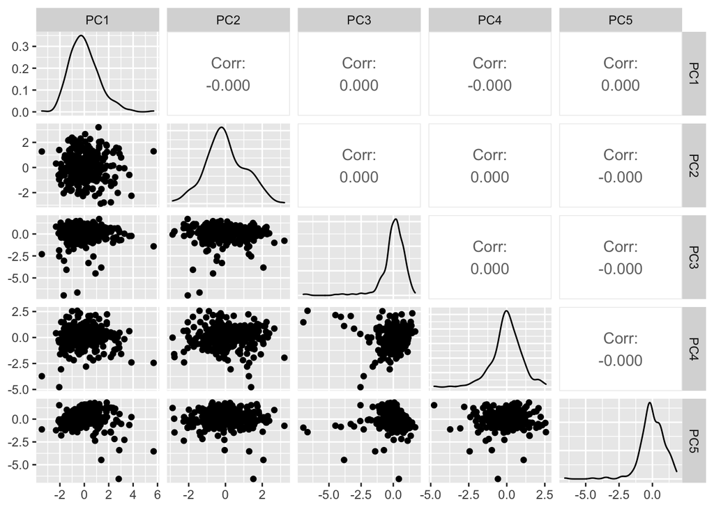

```r
heartdf <- data.frame(PC1 = heartpca$scores[,1], PC2 = heartpca$scores[,2], PC3= heartpca$scores[,3],PC4 = heartpca$scores[,4], PC5 = heartpca$scores[,5])
ggpairs(heartdf, columns = 1:5)
```

```r
summary(heartpca, loadings = T)
```

```
## Importance of components:
##                           Comp.1    Comp.2    Comp.3    Comp.4    Comp.5
## Standard deviation     1.2122875 1.0824323 1.0129344 0.9813227 0.9406195
## Proportion of Variance 0.2106532 0.1679416 0.1470685 0.1380322 0.1268192
## Cumulative Proportion  0.2106532 0.3785949 0.5256633 0.6636956 0.7905147
##                           Comp.6    Comp.7
## Standard deviation     0.8573076 0.8523593
## Proportion of Variance 0.1053490 0.1041363
## Cumulative Proportion  0.8958637 1.0000000
##
## Loadings:
##                          Comp.1 Comp.2 Comp.3 Comp.4 Comp.5 Comp.6 Comp.7
## age                       0.465  0.452         0.198  0.191  0.634  0.318
## creatinine_phosphokinase -0.138 -0.194 -0.815  0.334 -0.295  0.101  0.265
## ejection_fraction        -0.179  0.681  0.107        -0.469 -0.391  0.344
## platelets                -0.199  0.247 -0.403 -0.821  0.181  0.173
## serum_creatinine          0.512        -0.102 -0.182 -0.634  0.107 -0.529
## serum_sodium             -0.447  0.430 -0.118  0.363  0.151  0.187 -0.642
## time                     -0.481 -0.214  0.371 -0.100 -0.446  0.599  0.135
```

### Linear Classifier

```r
# linear classifier code here
fit <- glm(anaemia ~ age + creatinine_phosphokinase + ejection_fraction + platelets + serum_creatinine + serum_sodium + time, data = heart_failure, family= "binomial")
score <- predict(fit, type="response")
class_diag(score, heart_failure$anaemia, positive = 1)
```

```
##           acc   sens   spec    ppv     f1     ba    auc
## Metrics 0.612 0.4341 0.7471 0.5657 0.4912 0.5906 0.6489
```

```r
table(predict=as.numeric(score >.5),truth=heart_failure$anaemia)%>%addmargins
```

```
##        truth
## predict   0   1 Sum
##     0   127  73 200
##     1    43  56  99
##     Sum 170 129 299
```

```r
# cross-validation of linear classifier here
set.seed(1234)
k=10 #choose number of folds
heartdata<-heart_failure[sample(nrow(heart_failure)),] #randomly order rows
folds<-cut(seq(1:nrow(heart_failure)),breaks=k,labels=F) #create 10 folds
diags<-NULL
for(i in 1:k){
  ## Create training and test sets
  train<-heartdata[folds!=i,]
  test<-heartdata[folds==i,]
  truth<-test$anaemia
  ## Train model on training set
  fit<-glm(anaemia~.,data=train,family="binomial")
  probs<-predict(fit,newdata = test,type="response")
  ## Test model on test set (save all k results)
  diags<-rbind(diags,class_diag(probs,truth, positive=1))
}
summarize_all(diags,mean)
```

```
##       acc    sens    spec     ppv      f1     ba     auc
## 1 0.56137 0.37937 0.70042 0.50458 0.42318 0.5399 0.55897
```

The CV AUV indicates that this model is bad at predicting new observations with an AUC of 0.55897. There are signs of overfitting in this model, as the AUC of the initial linear regression is 0.6489, which is significantly higher than that of the CV AUC.

### Non-Parametric Classifier

```r
library(caret)
knn_fit <- knn3(factor(anaemia==1,levels=c("TRUE","FALSE")) ~., data=heart_failure, k=5)
y_hat_knn <- predict(knn_fit,heart_failure)
class_diag(y_hat_knn[,1],heart_failure$anaemia, positive=1)
```

```
##            acc   sens   spec    ppv    f1     ba    auc
## Metrics 0.6856 0.5969 0.7529 0.6471 0.621 0.6749 0.7636
```

```r
table(predicted=as.numeric(y_hat_knn[,1] >.5),actual=heart_failure$anaemia)%>%addmargins
```

```
##          actual
## predicted   0   1 Sum
##       0   128  52 180
##       1    42  77 119
##       Sum 170 129 299
```

```r
# cross-validation of np classifier here
set.seed(1234)
k=5 #choose number of folds
cvdata<-heart_failure %>% sample_frac() #randomly order rows
folds<-cut(seq(1:nrow(heart_failure)),breaks=k,labels=F) #create folds
diags<-NULL
for(i in 1:k){
  cvtrain<-cvdata[folds!=i,]
  cvtest<-cvdata[folds==i,]
  ## Fit linear regression model to training set
  cvfit<-knnreg(anaemia~.,data=cvtrain)
  ## Get predictions/y-hats on test set (fold i)
  cvyhat<-predict(cvfit,newdata=cvtest)
  ## Compute prediction error  (MSE) for fold i
  cvdiags<-mean((cvtest$anaemia-cvyhat)^2)
}
mean(cvdiags) ## get average MSE across all folds (much higher error)!
```

```
## [1] 0.3028333
```

### Regression/Numeric Prediction

```r
# regression model code here
lrfit<-lm(age~.,data=heart_failure) #predict mpg from all other variables
lryhat<-predict(lrfit) #predicted mpg
mean((heart_failure$age-lryhat)^2)
```

```
## [1] 123.3761
```

```r
# cross-validation of regression model here
set.seed(1234)
k=5 #choose number of folds
lcvdata<-heart_failure[sample(nrow(heart_failure)),] #randomly order rows
lcvfolds<-cut(seq(1:nrow(heart_failure)),breaks=k,labels=F) #create folds
diags<-NULL
for(i in 1:k){
  lcvtrain<-lcvdata[lcvfolds!=i,]
  lcvtest<-lcvdata[lcvfolds==i,]
  ## Fit linear regression model to training set
  lcvfit<-lm(age~.,data=lcvtrain)
  ## Get predictions/y-hats on test set (fold i)
  lcvyhat<-predict(fit,newdata=lcvtest)
  ## Compute prediction error  (MSE) for fold i
  lcvdiags<-mean((test$age-lcvyhat)^2)
}
mean(lcvdiags) ## get average MSE across all folds (much higher error)!
```

```
## [1] 3780.581
```

This model does show signs of overfitting as the CV MSE is much higher than the model error. The model error is 123.3761, while the MSE is 3780.581, which makes the MSE more than 10x times larger in the CV, indicating overfitting.

### Python

```r
library(reticulate)

math <- 59
```

```python
# python code here
math = 58
print(r.math + math)
```

```
## 117.0
```

```r
sum <- sum(math, py$math)
sum
```

```
## [1] 117
```

I stored the number 59 into a variable named “math” in the r code chunk, I then stored a number of 58 in a variable of the same name in the python chunk. I then utilized reticulate to access the r code math variable in the python chunk and then added the two and printed the sum. Utilizing reticulate again, I did a similar thing in the r code chunk, except this time accessing the python math variable and printing the sum.